# R Notebook

```r
library(lme4)
library(ggplot2)
library(plotrix)
library(visreg)
library(stringr)
library(tidyverse)
library(ggpubr)
library(gridExtra)
library(tidyverse)
library(tidymodels)
library(vip)
library(plm)
```

```r
new_format_lasso_data<- bind_rows(read_tsv("/Users/noa/Workspace/lasso_positions_sampling_results/f_lasso60.tsv"),
                                  read_tsv("/Users/noa/Workspace/lasso_positions_sampling_results/f_lasso30.tsv"),
                                  read_tsv("/Users/noa/Workspace/lasso_positions_sampling_results/f_lasso15.tsv")
                                  )
new_format_lasso_data<- new_format_lasso_data %>%
           separate(dataset_id, "_supermatrices_",
                into = c("prefix", "last_value"),
                remove = FALSE) %>% separate(last_value,"_",into = c("dataset_name", "suffix")) %>%  select(-c("prefix","suffix"))
```

Get a list of all relevant datasets

```r
new_format_lasso_data %>% distinct (dataset_name, MSA_original_n_seq, actual_n_seq, job_ind) %>% filter (actual_n_seq==30)
```

| MSA_original_n_seq | actual_n_seq | dataset_name | job_ind |
| --- | --- | --- | --- |
| 100 | 30 | StruA5 | 2 |
| 103 | 30 | WickA3 | 2 |
| 60 | 30 | NagyA1 | 0 |
| 96 | 30 | ShenA9 | 0 |
| 95 | 30 | YangA8 | 1 |
| 144 | 30 | MisoA2 | 1 |

Example MSA: Results are based on: /groups/pupko/noaeker/lasso_positions_sampling_results/f2_mg30/job_0/_groups_pupko_noaeker_data_supermatrices_edited__supermatrices_NagyA1_NagyA1.fasta/n_seq_30/n_loci_80000/Lasso_folder/exponential/training_4000_random_tree_eval/trimmed_4000/threshold_0.05_outputs/training_sitelh_df_prediction.csv

/groups/pupko/noaeker/lasso_positions_sampling_results/f2_mg30/job_0/_groups_pupko_noaeker_data_supermatrices_edited__supermatrices_NagyA1_NagyA1.fasta/n_seq_30/n_loci_80000/Lasso_folder/exponential/training_4000_random_tree_eval/trimmed_4000/threshold_0.05_outputs/test_sitelh_df_prediction_no_opt.csv

```r
example_msa_data<- new_format_lasso_data %>% filter (dataset_name=="NagyA1", actual_n_seq==30, actual_n_loci == 80000)

example_msa_data_specific_configuration<- example_msa_data %>% filter (actual_sample_pct==0.05, actual_training_size==4000)

example_msa_data_specific_configuration %>% select (alpha, number_loci_chosen, `lasso_test_R^2`, lasso_test_spearmanr )
```

| alpha | number_loci_chosen | lasso_test_R^2 | lasso_test_spearmanr |
| --- | --- | --- | --- |
| 0.936674 | 4048 | 0.9983101 | 0.9983198 |

```r
example_msa_training_ll<- read_csv("/Users/noa/Workspace/lasso_positions_sampling_results/NagyA1_training.csv")
g01<-ggplot(example_msa_test_ll,aes(true_test_ll, predicted_test_ll)) +theme_classic()+
  geom_smooth(method='lm')+xlab("True LL")+ylab("Predicted LL ")+geom_point()+ labs(title="")+theme(plot.title = element_text(hjust = 0.5))+ theme(plot.title = element_text(hjust = 0.5))+ theme(text = element_text(size = 15))

g02<-ggplot(example_msa_training_ll,aes(true_training_ll, predicted_training_ll)) +theme_classic()+
  geom_smooth(method='lm')+xlab("True LL")+ylab("Predicted LL ")+geom_point()+ labs(title="")+theme(plot.title = element_text(hjust = 0.5))+ theme(plot.title = element_text(hjust = 0.5))+theme(text = element_text(size = 15))

figure_1<-ggarrange(g02, g01, hjust=-1,vjust=1, heights=c(2,2),common.legend=TRUE,
          labels = c("A", "B"),
          ncol = 1, nrow =2)
figure_1
```

[output not shown]

```r
ggsave("Figure_1.jpeg",
       plot = figure_1, dpi = 350)
dev.off()
```

```r
r2.taining<- cor.test(example_msa_training_ll$predicted_training_ll,example_msa_training_ll$true_training_ll )
r2.test<- cor.test(example_msa_test_ll$predicted_test_ll,example_msa_test_ll$true_test_ll )

r2.taining
```

```
    Pearson's product-moment correlation

data:  example_msa_training_ll$predicted_training_ll and example_msa_training_ll$true_training_ll
t = 30993, df = 3998, p-value < 2.2e-16
alternative hypothesis: true correlation is not equal to 0
95 percent confidence interval:
 0.9999978 0.9999980
sample estimates:
      cor
0.9999979
```

```r
r2.test
```

```
    Pearson's product-moment correlation

data:  example_msa_test_ll$predicted_test_ll and example_msa_test_ll$true_test_ll
t = 240.61, df = 98, p-value < 2.2e-16
alternative hypothesis: true correlation is not equal to 0
95 percent confidence interval:
 0.9987417 0.9994322
sample estimates:
      cor
0.9991547
```

```r
r2.taining.spearman<- cor.test(example_msa_training_ll$predicted_training_ll,example_msa_training_ll$true_training_ll, method = "spearman" )
r2.test.spearman<- cor.test(example_msa_test_ll$predicted_test_ll,example_msa_test_ll$true_test_ll, method = "spearman" )

r2.taining.spearman
```

```
    Spearman's rank correlation rho

data:  example_msa_training_ll$predicted_training_ll and example_msa_training_ll$true_training_ll
S = 35162, p-value < 2.2e-16
alternative hypothesis: true rho is not equal to 0
sample estimates:
      rho
0.9999967
```

```r
r2.test.spearman
```

```
    Spearman's rank correlation rho

data:  example_msa_test_ll$predicted_test_ll and example_msa_test_ll$true_test_ll
S = 280, p-value < 2.2e-16
alternative hypothesis: true rho is not equal to 0
sample estimates:
      rho
0.9983198
```

```r
train_errors<-example_msa_training_ll %>% mutate(error_pct = round(abs((true_training_ll-predicted_training_ll)/true_training_ll)*100,3))
train_errors %>% head(5)
```

| X1 | predicted_training_ll | true_training_ll | error_pct |
| --- | --- | --- | --- |
| 0 | -2521336 | -2521361 | 0.001 |
| 1 | -2492530 | -2492400 | 0.005 |
| 2 | -2682863 | -2683108 | 0.009 |
| 3 | -2491175 | -2491191 | 0.001 |
| 4 | -2463170 | -2463144 | 0.001 |

```r
test_errors<-example_msa_test_ll %>% mutate(error_pct = round(abs((true_test_ll-predicted_test_ll)/true_test_ll)*100,3))
test_errors %>% head (5)
```

| X1 | predicted_test_ll | true_test_ll | error_pct |
| --- | --- | --- | --- |
| 0 | -2186578 | -2182258 | 0.198 |
| 1 | -2177329 | -2172831 | 0.207 |
| 2 | -2201897 | -2198910 | 0.136 |
| 3 | -2137834 | -2132178 | 0.265 |
| 4 | -2174970 | -2170487 | 0.207 |

```r
train_errors %>% summarise(median_error_pct = median(error_pct))
```

| median_error_pct |
| --- |
| 0.003 |

```r
test_errors %>% summarise(median_error_pct = median(error_pct))
```

| median_error_pct |
| --- |
| 0.173 |

```r
NA
NA
```

Explore unexplained variance on example MSA

```r
example_msa_data <- example_msa_data %>% mutate(unexplained_var =1-`lasso_test_R^2`)

example_msa_data %>% select (actual_training_size, actual_sample_pct,`lasso_test_R^2`, unexplained_var)
```

| actual_training_size | actual_sample_pct | lasso_test_R^2 | unexplained_var |
| --- | --- | --- | --- |
| 500 | 0.010 | 0.9779993 | 0.022000686 |
| 500 | 0.025 | 0.9781494 | 0.021850641 |
| 500 | 0.050 | 0.9781834 | 0.021816584 |
| 1000 | 0.010 | 0.9837544 | 0.016245633 |
| 1000 | 0.025 | 0.9884911 | 0.011508860 |
| 1000 | 0.050 | 0.9885830 | 0.011416989 |
| 1000 | 0.100 | 0.9886269 | 0.011373077 |
| 2000 | 0.010 | 0.9825075 | 0.017492477 |
| 2000 | 0.025 | 0.9956023 | 0.004397734 |
| 2000 | 0.050 | 0.9966570 | 0.003343003 |

[output cut: 5 more lines]

```r
figure_2<-example_msa_data %>% ggplot(aes(x=actual_sample_pct,y=unexplained_var, group = as.factor(actual_training_size), colour = as.factor(actual_training_size)))  + geom_point(size =3)+ geom_line()+ scale_x_continuous(breaks = c(0.01,0.025,0.05,0.1) ,labels = scales::percent) +labs(color="Training size",x="Sample percentage",y="Unexplained variance (%)")  + scale_y_continuous(labels = scales::percent)+theme_classic() + theme(text = element_text(size = 15))


ggsave("Figure_2.jpeg",
       plot = figure_2, dpi = 350)
```

```r
supp_data2<- example_msa_data %>% select (actual_training_size, actual_sample_pct,number_loci_chosen, unexplained_var)

supp_data2 %>% write_csv("/Users/noa/Workspace/lasso_positions_sampling_results/supp2.csv")
```

r4s on one msa: Based on: 1./groups/pupko/noaeker/lasso_positions_sampling_results/f_lasso30/job_0/_groups_pupko_noaeker_data_supermatrices_edited__supermatrices_NagyA1_NagyA1.fasta/n_seq_30/n_loci_80000/r4s.res /Users/noa/Workspace/lasso_positions_sampling_results/r4s_NAGY_res.full

2. /groups/pupko/noaeker/lasso_positions_sampling_results/f2_mg30/job_0/_groups_pupko_noaeker_data_supermatrices_edited__supermatrices_NagyA1_NagyA1.fasta/n_seq_30/n_loci_80000/Lasso_folder/exponential/training_4000_random_tree_eval/trimmed_4000/lasso_rate_4_site /Users/noa/Workspace/lasso_positions_sampling_results/r4s_NAGY_res.lasso

```r
full_r4s<- read_csv("/Users/noa/Workspace/lasso_positions_sampling_results/NagyA1_full_rate4site")
lasso_r4s<- read_csv("/Users/noa/Workspace/lasso_positions_sampling_results/NagyA1_lasso_rate4site")
full_r4s<- full_r4s %>% mutate(data = "All MSA positions")
full_r4s
```

| Numbers | data |
| --- | --- |
| -0.122000 | All MSA positions |
| 1.011000 | All MSA positions |
| 0.614500 | All MSA positions |
| -0.122000 | All MSA positions |
| -0.851000 | All MSA positions |
| -0.932100 | All MSA positions |
| 0.010890 | All MSA positions |
| -0.932100 | All MSA positions |
| -0.835500 | All MSA positions |
| -0.694200 | All MSA positions |

[output cut: 990 more lines]

```r
lasso_r4s<- lasso_r4s %>% mutate(data = "Positions chosen by Lasso")
lasso_r4s
```

| Numbers | data |
| --- | --- |
| 0.3006000 | Positions chosen by Lasso |
| -0.4381000 | Positions chosen by Lasso |
| -0.6162000 | Positions chosen by Lasso |
| -0.6108000 | Positions chosen by Lasso |
| -0.0485000 | Positions chosen by Lasso |
| 0.6417000 | Positions chosen by Lasso |
| 0.7143000 | Positions chosen by Lasso |
| 0.2794000 | Positions chosen by Lasso |
| 0.1662000 | Positions chosen by Lasso |
| -0.5272000 | Positions chosen by Lasso |

[output cut: 990 more lines]

```r
all_r4s_data<-rbind(full_r4s,lasso_r4s)
all_r4s_data
```

| Numbers | data |
| --- | --- |
| -0.122000 | All MSA positions |
| 1.011000 | All MSA positions |
| 0.614500 | All MSA positions |
| -0.122000 | All MSA positions |
| -0.851000 | All MSA positions |
| -0.932100 | All MSA positions |
| 0.010890 | All MSA positions |
| -0.932100 | All MSA positions |
| -0.835500 | All MSA positions |
| -0.694200 | All MSA positions |

[output cut: 990 more lines]

```r
figure_3<-all_r4s_data %>% ggplot(aes(x = Numbers, fill = data)) +
geom_histogram(bins=8,aes(y=..density..),
                 alpha=0.5,position='identity',binwidth=0.5) + labs(fill = "", x = "Standartaized rates", y= "Density") +theme_classic()+ theme(text = element_text(size = 15))

summary(lasso_r4s %>% pull(Numbers))
```

```
   Min. 1st Qu.  Median    Mean 3rd Qu.    Max.
-1.2200 -0.1905  0.4846  0.6313  1.3125  3.1440
```

```r
ttest<-t.test(lasso_r4s %>% pull(Numbers),full_r4s%>%pull(Numbers))

ggsave("Figure_3.jpeg",
       plot = figure_3, dpi = 350)
```

Explore unexplained variance on all MSAs

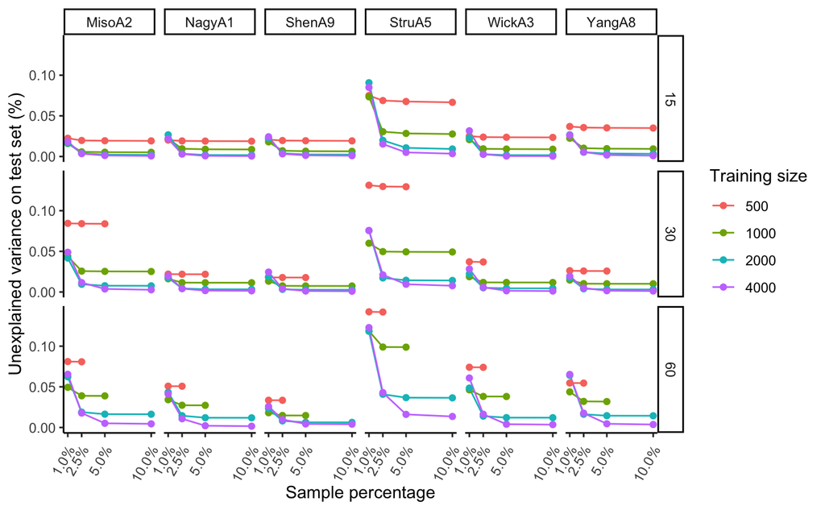

```r
supp_data2<- new_format_lasso_data %>% select(dataset_name,actual_n_seq, actual_n_loci,actual_training_size, actual_sample_pct, number_loci_chosen ,`lasso_test_R^2`) %>% arrange(dataset_name)

supp_data2 %>% write_csv("/Users/noa/Workspace/lasso_positions_sampling_results/supp2.csv")


new_format_lasso_data  %>%  mutate (unexplained_var = 1-`lasso_test_R^2`) %>%
  filter (actual_n_loci==80000) %>%
  ggplot(aes(x=actual_sample_pct,y=unexplained_var, group = interaction(actual_training_size,dataset_name), color = as.factor(actual_training_size)))+ geom_line() + geom_point(size=1.5) + scale_x_continuous(labels = scales::percent,breaks = c(0.01,0.025,0.05,0.1)) +labs(color="Training size" ,x="Sample percentage",y="Unexplained variance on test set (%)") + theme_classic()+facet_grid(cols = vars(dataset_name), rows=  vars(actual_n_seq)) + theme(axis.text.x = element_text(angle = 60, vjust = 0.9, hjust=1))
```

```r
NA
NA
```

New lme analysis

```r
library(nlme)
library(rsq)

lasso_glm_data<- new_format_lasso_data  %>% filter (actual_training_size==4000, actual_sample_pct==0.05) %>% select (`lasso_test_R^2`,actual_n_seq,actual_n_loci,dataset_name,divergence, constant_sites_pct, lasso_mean_rate4site,avg_entropy,alpha ) %>% mutate (unexplained_var =1-`lasso_test_R^2` )
lasso_glm_data
```

| lasso_test_R^2 | actual_n_seq | actual_n_loci | dataset_name | divergence | constant_sites_pct | lasso_mean_rate4site | avg_entropy | alpha | unexplained_var |
| --- | --- | --- | --- | --- | --- | --- | --- | --- | --- |
| 0.9804061 | 60 | 20000 | ShenA9 | 19.835239 | 0.1073000 | 0.5375974 | 1.0909359 | 0.807038 | 0.0195938732 |
| 0.9914672 | 60 | 40000 | ShenA9 | 20.792784 | 0.1041750 | 0.5584364 | 1.1245202 | 0.804812 | 0.0085327826 |
| 0.9956536 | 60 | 80000 | ShenA9 | 20.580550 | 0.1029750 | 0.5443802 | 1.1335860 | 0.817027 | 0.0043464496 |
| 0.9739191 | 60 | 20000 | NagyA1 | 17.311737 | 0.2281500 | 0.7771271 | 0.7734941 | 0.858261 | 0.0260808812 |
| 0.9932437 | 60 | 40000 | NagyA1 | 17.665041 | 0.2236750 | 0.7520205 | 0.7822350 | 0.847071 | 0.0067563421 |
| 0.9978513 | 60 | 80000 | NagyA1 | 20.956806 | 0.2140125 | 0.6795327 | 0.8510265 | 0.871635 | 0.0021487136 |
| 0.9709895 | 60 | 20000 | YangA8 | 7.684873 | 0.2807000 | 1.1096462 | 0.5409987 | 0.564945 | 0.0290105017 |
| 0.9861504 | 60 | 40000 | YangA8 | 7.276783 | 0.2892500 | 1.0867068 | 0.5324726 | 0.564856 | 0.0138496361 |
| 0.9954603 | 60 | 80000 | YangA8 | 7.397027 | 0.3008125 | 1.0515737 | 0.5312356 | 0.544702 | 0.0045397464 |
| 0.9620728 | 60 | 20000 | MisoA2 | 13.130251 | 0.0000000 | 1.0072876 | 0.9906419 | 0.644515 | 0.0379271902 |

[output cut: 44 more lines]

```r
lasso_mixed = lme(log(unexplained_var)/(1-unexplained_var) ~ (actual_n_loci+actual_n_seq+divergence+constant_sites_pct+alpha ), random = ~ 1 | dataset_name, data = lasso_glm_data)
print(summary(lasso_mixed))
```

```
Linear mixed-effects model fit by REML
  Data: lasso_glm_data
```

|  | AIC | BIC | logLik |
| --- | --- | --- | --- |
|  | 112.7662 | 127.7358 | -48.38312 |

```
Random effects:
 Formula: ~1 | dataset_name
        (Intercept) Residual
StdDev:   0.2357355 0.398658

Fixed effects:  log(unexplained_var)/(1 - unexplained_var) ~ (actual_n_loci +      actual_n_seq + divergence + constant_sites_pct + alpha)
```

|  | Value | Std.Error | DF | t-value | p-value |
| --- | --- | --- | --- | --- | --- |
| (Intercept) | -3.675684 | 0.4259620 | 43 | -8.629134 | 0.0000 |
| actual_n_loci | -0.000029 | 0.0000022 | 43 | -13.112443 | 0.0000 |
| actual_n_seq | 0.030442 | 0.0069275 | 43 | 4.394456 | 0.0001 |
| divergence | -0.015510 | 0.0295018 | 43 | -0.525722 | 0.6018 |
| constant_sites_pct | -1.160128 | 0.7762306 | 43 | -1.494567 | 0.1423 |
| alpha | -1.234466 | 0.5674494 | 43 | -2.175465 | 0.0351 |

```
 Correlation:
                   (Intr) actl_n_l actl_n_s dvrgnc cnst__
actual_n_loci      -0.302
actual_n_seq       -0.547  0.108
divergence          0.431 -0.120   -0.890
constant_sites_pct -0.167 -0.007    0.074    0.117
alpha              -0.817  0.081    0.511   -0.583 -0.249

Standardized Within-Group Residuals:
       Min         Q1        Med         Q3        Max
-2.3681922 -0.6683009 -0.2211094  0.8273177  1.7396322

Number of Observations: 54
Number of Groups: 6
```

```r
print(rsq(lasso_mixed))
```

```
$model
[1] 0.8879164

$fixed
[1] 0.8581956

$random
[1] 0.02972085
```

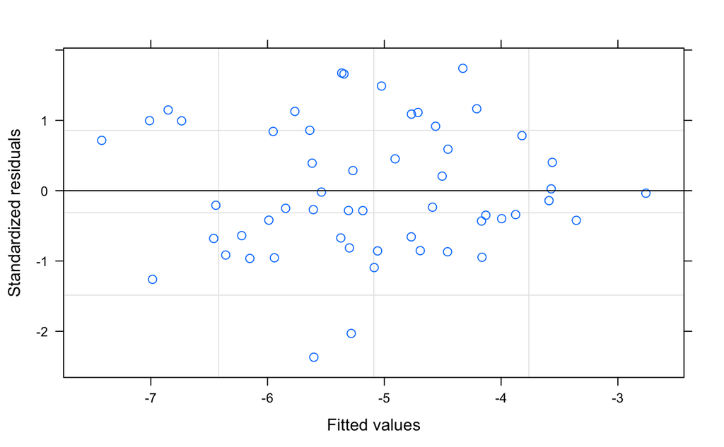

```r
plot.lme((lasso_mixed))
```